# Analyzing project days’ engagement v2

We import the observation and questionnaire data…

Initial explorations of observation data:

```r
obsdata <- processAllObservationData()
actdata <- load_all_intermediate_questionnaires()
findata <- load_all_final_questionnaires()
```

*One thing to note: on the 2017-10-11 event, the observation of technology and resources was conflated into a single observer tick – the current preprocessing assumes that the tick means “engaged with technology AND resources” (and the absence of tick, not engaged with either technology or resources)*

A potential way of answering this with MCA analysis:

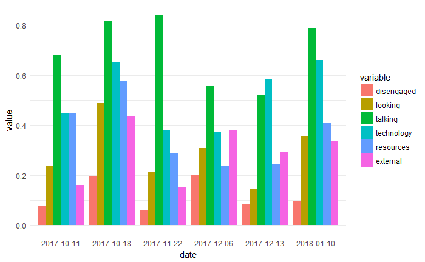

```r
obsdata %>% dplyr::select(date, project, disengaged:external) %>%
  aggregate(.~date+project,data=., mean) %>%
  dplyr::mutate(date=as.factor(date)) %>%
  melt(id.vars=c("date","project")) %>%
  ggplot(aes(date, value)) +
  geom_bar(aes(fill=variable), position = "dodge", stat = "identity") + theme_minimal()
```

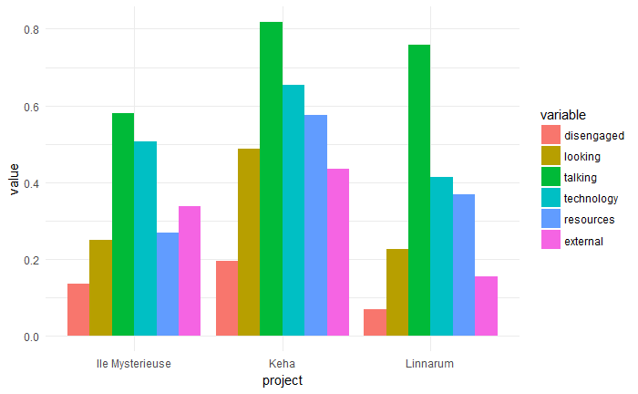

```r
obsdata %>% dplyr::select(project, disengaged:external) %>% aggregate(.~project,data=., mean) %>%
  melt(id.vars="project") %>%
  ggplot(aes(project, value)) +
  geom_bar(aes(fill=variable), position = "dodge", stat = "identity") + theme_minimal()
```

- MCADim1 explains most (25%) of the variance, and it seems very correlated with disengagement behavior (and somewhat with more passive forms of engagement like looking), and viceversa: negative values are related with the other, more active kinds of engagement (external, resources, technology, talking). We can interpret –MCADim1 as **“Active engagement”**.
- –MCADim2 could be related with some kind of **“Passive engagement”** (introspection?), since it is quite correlated with looking and talking (but not use of external, techology, or disengagement).
- MCADim3 is related with external and looking, maybe in the sense of **“confusion and help-seeking”**? (but this is maybe a stretch)

With these interpretations, we can now get the profile of each day, each project, and each student or group:

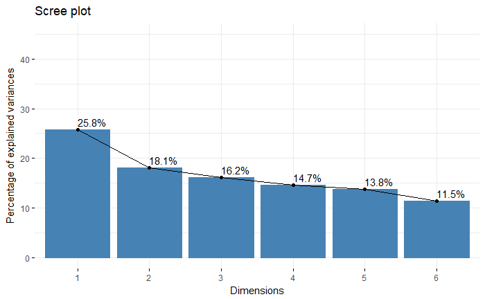

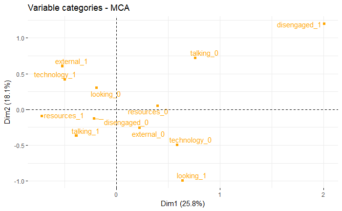

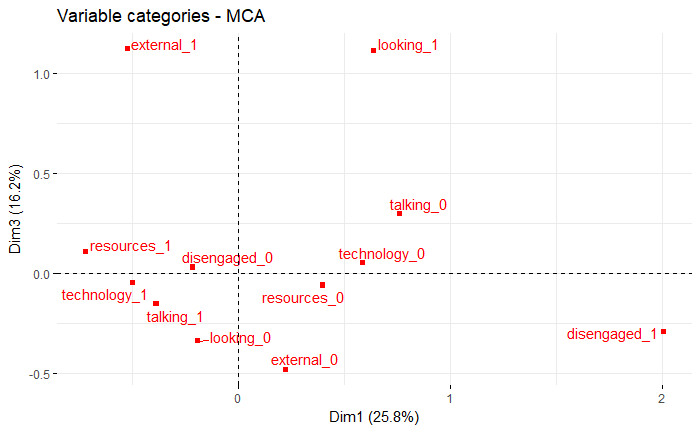

```r
mca <- mca_analysis(obsdata, plots = T)
```

```r
#  fviz_ellipses(mca, "disengaged", geom = "point")
obsdata <- add_mca_dimensions(obsdata, mca = mca, dimensions = 3)
obsdata <- obsdata %>% mutate(MCA.Active.Eng = -MCAdim1) %>%
   mutate(MCA.Passive.Eng = -MCAdim2) %>%
   mutate(MCA.Conf.Help = MCAdim3)
```

… and we can also see the evolution of these variables over time, globally, per student and per group

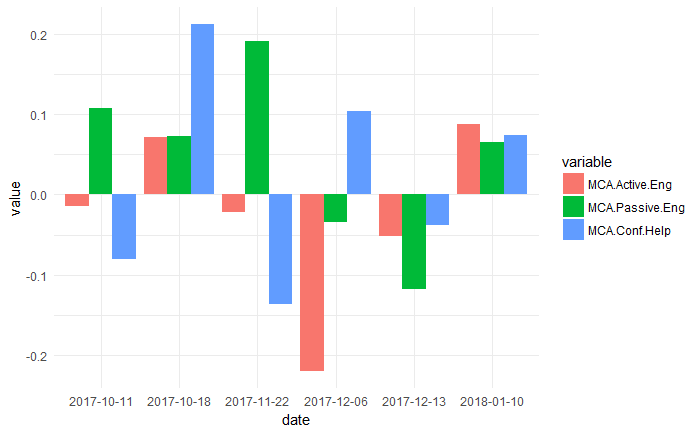

```r
obsdata %>% dplyr::select(date, project, MCA.Active.Eng:MCA.Conf.Help) %>%
  aggregate(.~date+project,data=., mean) %>%
  dplyr::mutate(date=as.factor(date)) %>%
  melt(id.vars=c("date","project")) %>%
  ggplot(aes(date, value)) +
  geom_bar(aes(fill=variable), position = "dodge", stat = "identity") + theme_minimal()
```

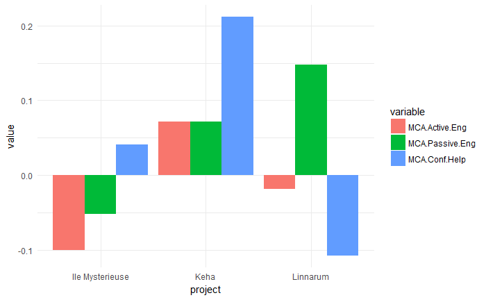

```r
obsdata %>% dplyr::select(project, MCA.Active.Eng:MCA.Conf.Help) %>% aggregate(.~project,data=., mean) %>%
  melt(id.vars="project") %>%
  ggplot(aes(project, value)) +
  geom_bar(aes(fill=variable), position = "dodge", stat = "identity") + theme_minimal()
```

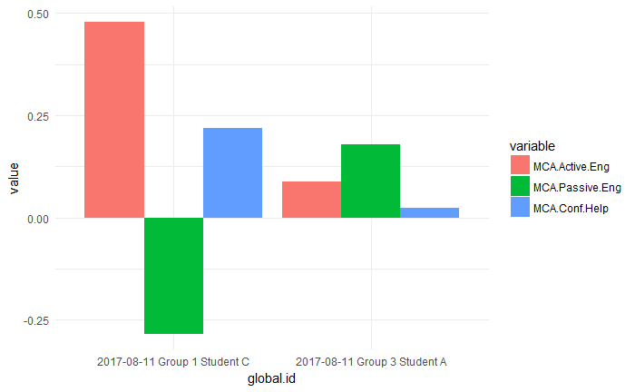

```r
obsdata %>% dplyr::select(global.id, MCA.Active.Eng:MCA.Conf.Help) %>% aggregate(.~global.id,data=., mean) %>%
  melt(id.vars="global.id") %>%
  filter(global.id=="2017-08-11 Group 1 Student C" | global.id=="2017-08-11 Group 3 Student A") %>%
  ggplot(aes(global.id, value)) +
  geom_bar(aes(fill=variable), position = "dodge", stat = "identity") + theme_minimal()
```

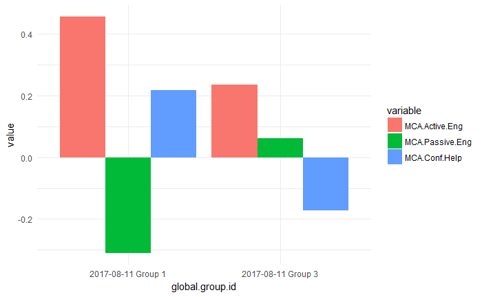

```r
obsdata %>% mutate(global.group.id=paste(date,group)) %>%
  dplyr::select(global.group.id, MCA.Active.Eng:MCA.Conf.Help) %>% aggregate(.~global.group.id,data=., mean) %>%
  melt(id.vars="global.group.id") %>%
  filter(global.group.id=="2017-08-11 Group 1" | global.group.id=="2017-08-11 Group 3") %>%
  ggplot(aes(global.group.id, value)) +
  geom_bar(aes(fill=variable), position = "dodge", stat = "identity") + theme_minimal()
```

If we now compare these MCA dimensions of engagement with the responses to the final questionnaire (difficulty –actually, ease; and satisfaction):

```r
obtotal <- obsdata %>% dplyr::select(global.id, disengaged:external, MCA.Active.Eng:MCA.Conf.Help) %>% aggregate(.~global.id,data=., mean)

merged <- merge(obtotal,findata, by="global.id") %>% dplyr::select(global.id, disengaged:external, MCA.Active.Eng:MCA.Conf.Help, satisfaction, difficulty)

merged %>% dplyr::select(-global.id) %>% chart.Correlation(histogram=TRUE, pch=19)
```

[output not shown]

Do these dimensions (or the autoencoder) take away some of the observer noise (in IRR)? Apparently not

## Adding the HMM and auto-encoder variables

[figure not shown]

```r
create_hmm_states_global(obsdata, visualise = TRUE, max_states = 6)
```

```
Error in object$metrics : $ operator not defined for this S4 class
```